# NPRB - Hogan Bay Exploratory Analysis with 298 Markers

# Introduction

This is a quick exploratory analysis of the NPRB Hogan Bay 2013-2016 genotype data. Here we will:

- Create *LocusControl*
- Read in all project genotypes
- Remove the 6 problematic loci Tyler identified
- Read in paired field/otoltih data from [OceanAK](http://www.oceanak.adfg.alaska.gov/)
- Join paired data from OceanAK
  - Will need to create data key for join (DWP barcode + “_" + DWP position number)
- Determine *FailureRate*
- Perform QA on project gentoypes
  - Removing fish missing >= 20% of genotypes
  - Remove within collection duplicates
  - Explore the use of a **heterozygosity** filter to remove individuals with bogus genotype calls
  - Save final, post-QA genotypes with paired data
- Explore genetic structure
  - Among brood lines (even/odd)
  - Among years
  - Among hatchery/wild (note different hatcheries have different brood sources)
- Export genotypes as a *Genepop* file to feed in to *genepop2franz.GCL.r*

# Read in genotypes

Create *LocusControl* and read in genotypes by *silly*

```r
sillyvec <- ProjectSillys <- c("PHOGAN13", "PHOGAN14", "PHOGAN15", "PHOGAN16")
markersuite <- "Pink_PWS_304"
CreateLocusControl.GCL(markersuite = markersuite, username = .username, password = .password)
```

```
[1] "LocusControl created for markersuite='Pink_PWS_304'"
```

```r
loci304 <- LocusControl$locusnames
loci6_remove <- c("Ogo_RAD8604", "Ogo_RAD25769", "Ogo_RAD25777", "Ogo_RAD42336", "Ogo_RAD75881", "Ogo_RAD9934")
loci298 <- sort(setdiff(loci304, loci6_remove))
rm(LocusControl)
CreateLocusControl.GCL(locusnames = loci298, username = .username, password = .password)
```

```
[1] "LocusControl created for markersuite='User defined from locusnames'"
```

```r
loci <- LocusControl$locusnames
nalleles <- LocusControl$nalleles
ploidy <- LocusControl$ploidy
alleles <- LocusControl$alleles
load_sillys(path = "../Genotypes/304/Original/")
```

```
[1] "PHOGAN13" "PHOGAN14" "PHOGAN15" "PHOGAN16"
```

```r
rm(.username, .password)
```

# Filter for 298 Loci

```r
PHOGAN13.gcl$counts <- PHOGAN13.gcl$counts[, loci298, ]
PHOGAN14.gcl$counts <- PHOGAN14.gcl$counts[, loci298, ]
PHOGAN15.gcl$counts <- PHOGAN15.gcl$counts[, loci298, ]
PHOGAN16.gcl$counts <- PHOGAN16.gcl$counts[, loci298, ]
PHOGAN13.gcl$scores <- PHOGAN13.gcl$scores[, loci298, ]
PHOGAN14.gcl$scores <- PHOGAN14.gcl$scores[, loci298, ]
PHOGAN15.gcl$scores <- PHOGAN15.gcl$scores[, loci298, ]
PHOGAN16.gcl$scores <- PHOGAN16.gcl$scores[, loci298, ]
```

Save objects

```r
save_objects(objects = c("LocusControl", "loci", "sillyvec", "ProjectSillys"), path = "../Objects")
save_sillys(sillyvec = sillyvec, path = "../Genotypes/298/")
save_objects(objects = c("loci304", "loci298", "loci6_remove"), path = "../Objects")
```

# OceanAK

## Read data

Read in paired field and otolith data from *OceanAK*, join that data to the attributes table of each silly object.

```r
AHRP_oceanak <- read_csv("v:/Analysis/5_Coastwide/Multispecies/Alaska Hatchery Research Program/PWS Pink/OceanAK/PedigreeData_AHRP - Salmon Biological Data 2_PWS_2013-2018_no_otoliths.csv")
hogan_oceanak <- AHRP_oceanak %>%
  dplyr::filter(`Location Code` == "Hogan Creek") %>%
  tidyr::unite(silly_source, c("Silly Code", "Fish ID"), sep = "_", remove = FALSE)
```

## Join attributes table

Join *hogan_oceanak* data to the attributes table of each silly. Already looked to verify that no tissues were missing or duplicated, this makes sense because the lab can’t genotype tissue that aren’t there and they never genotype two samples in a well.

```r
PHOGAN13.gcl$attributes <- PHOGAN13.gcl$attributes %>%
  dplyr::left_join(hogan_oceanak, by = c("SillySource" = "silly_source")) %>%
  dplyr::select(FK_FISH_ID, SILLY_CODE, PLATE_ID, DNA_TRAY_CODE, DNA_TRAY_WELL_CODE, SillySource, `Sample Date`, Sex, `Length Mm`, `Location Code`, `Otolith Mark Present`, `Otolith Mark ID`, `Sample Year`)
PHOGAN14.gcl$attributes <- PHOGAN14.gcl$attributes %>%
  dplyr::left_join(hogan_oceanak, by = c("SillySource" = "silly_source")) %>%
  dplyr::select(FK_FISH_ID, SILLY_CODE, PLATE_ID, DNA_TRAY_CODE, DNA_TRAY_WELL_CODE, SillySource, `Sample Date`, Sex, `Length Mm`, `Location Code`, `Otolith Mark Present`, `Otolith Mark ID`, `Sample Year`)
PHOGAN15.gcl$attributes <- PHOGAN15.gcl$attributes %>%
  dplyr::left_join(hogan_oceanak, by = c("SillySource" = "silly_source")) %>%
  dplyr::select(FK_FISH_ID, SILLY_CODE, PLATE_ID, DNA_TRAY_CODE, DNA_TRAY_WELL_CODE, SillySource, `Sample Date`, Sex, `Length Mm`, `Location Code`, `Otolith Mark Present`, `Otolith Mark ID`, `Sample Year`)
PHOGAN16.gcl$attributes <- PHOGAN16.gcl$attributes %>%
  dplyr::left_join(hogan_oceanak, by = c("SillySource" = "silly_source")) %>%
  dplyr::select(FK_FISH_ID, SILLY_CODE, PLATE_ID, DNA_TRAY_CODE, DNA_TRAY_WELL_CODE, SillySource, `Sample Date`, Sex, `Length Mm`, `Location Code`, `Otolith Mark Present`, `Otolith Mark ID`, `Sample Year`)
save_sillys(sillyvec = sillyvec, path = "../Genotypes/298/OceanAK/")
```

## Split by otolith-origin

First we need to verify that we only have hatchery and natural-origin fish for the **F0** years (2013 & 2014), and only natural-origin fish for the **F1** years (2015 & 2016).

```r
dplyr::bind_rows(PHOGAN13.gcl$attributes,
                 PHOGAN14.gcl$attributes,
                 PHOGAN15.gcl$attributes,
                 PHOGAN16.gcl$attributes) %>%
  count(SILLY_CODE, `Otolith Mark Present`) %>%
  spread(`Otolith Mark Present`, n, fill = 0)
```

| SILLY_CODE | NO | YES | <NA> |
| --- | --- | --- | --- |
| PHOGAN13 | 334 | 461 | 0 |
| PHOGAN14 | 239 | 512 | 0 |
| PHOGAN15 | 2100 | 36 | 7 |
| PHOGAN16 | 4295 | 0 | 0 |

Ruh-roh, looks like we ended up with some hatchery-origin fish and some unknown origin fish (NA) in 2015, when they all should have been natural-origin. This is likely due to a discrepancy between first otolith reads and second otolith reads (i.e. fish were picked for extraction after first reads when all were thought to be natural-origin, but the second read overwrote). We will want to remove those fish (43 total) from PHOGAN15.

```r
PHOGAN15_ids_remove <- PHOGAN15.gcl$attributes %>%
  filter(`Otolith Mark Present` == "YES" | is.na(`Otolith Mark Present`)) %>%
  mutate(FK_FISH_ID = as.character(FK_FISH_ID)) %>%
  pull(FK_FISH_ID)
RemoveIDs.GCL(silly = "PHOGAN15", IDs = PHOGAN15_ids_remove)
```

Now that we have removed those fish that we did not want due to their otolith status, we will split 2013 & 2014 by otolith-origin. Also create a new *sillyvec*.

```r
PHOGAN13_ids_natural <- list("PHOGAN13" = PHOGAN13.gcl$attributes %>%
  filter(`Otolith Mark Present` == "NO") %>%
  mutate(FK_FISH_ID = as.character(FK_FISH_ID)) %>%
  pull(FK_FISH_ID))
PoolCollections.GCL(collections = "PHOGAN13", loci = loci, IDs = PHOGAN13_ids_natural, newname = "PHOGAN13n")
```

```r
PHOGAN13_ids_hatchery <- list("PHOGAN13" = PHOGAN13.gcl$attributes %>%
  filter(`Otolith Mark Present` == "YES") %>%
  mutate(FK_FISH_ID = as.character(FK_FISH_ID)) %>%
  pull(FK_FISH_ID))
PoolCollections.GCL(collections = "PHOGAN13", loci = loci, IDs = PHOGAN13_ids_hatchery, newname = "PHOGAN13h")
```

```r
PHOGAN14_ids_natural <- list("PHOGAN14" = PHOGAN14.gcl$attributes %>%
  filter(`Otolith Mark Present` == "NO") %>%
  mutate(FK_FISH_ID = as.character(FK_FISH_ID)) %>%
  pull(FK_FISH_ID))
PoolCollections.GCL(collections = "PHOGAN14", loci = loci, IDs = PHOGAN14_ids_natural, newname = "PHOGAN14n")
```

```r
PHOGAN14_ids_hatchery <- list("PHOGAN14" = PHOGAN14.gcl$attributes %>%
  filter(`Otolith Mark Present` == "YES") %>%
  mutate(FK_FISH_ID = as.character(FK_FISH_ID)) %>%
  pull(FK_FISH_ID))
PoolCollections.GCL(collections = "PHOGAN14", loci = loci, IDs = PHOGAN14_ids_hatchery, newname = "PHOGAN14h")
```

```r
ProjectSillys_Origin <- c("PHOGAN13n", "PHOGAN13h", "PHOGAN14n", "PHOGAN14h", "PHOGAN15", "PHOGAN16")
save_sillys(ProjectSillys_Origin, "../Genotypes/298/OceanAK_Origin/")
```

# Failure rate

Calculate and view the failure rate by silly, locus, and plate.

| silly | fail |
| --- | --- |
| PHOGAN14 | 0.08045201 |
| PHOGAN15 | 0.03696868 |
| PHOGAN13 | 0.03024355 |
| PHOGAN16 | 0.02720816 |

| locus | fail |
| --- | --- |
| Ogo_RAD24331 | 0.423624229 |
| Ogo_RAD18621 | 0.327162826 |
| Ogo_RAD77424 | 0.285984133 |
| Ogo_RAD21635 | 0.275532049 |
| Ogo_RAD50499 | 0.219997481 |
| Ogo_RAD24703 | 0.203626747 |
| Ogo_RAD10094 | 0.179196575 |
| Ogo_RAD30883 | 0.145573605 |
| Ogo_RAD69356 | 0.130839945 |
| Ogo_RAD523 | 0.128825085 |

[output cut: 288 more lines]

| plate | fail |
| --- | --- |
| 59136/60051 | 1.000000000 |
| 59151/60052 | 1.000000000 |
| 59177/60054 | 0.838926174 |
| 59174/60054 | 0.742729306 |
| 58544/60047 | 0.688449311 |
| 58541/60047 | 0.657718121 |
| 58543 | 0.605145414 |
| 59145/60051 | 0.603068073 |
| 58544/60049 | 0.573266219 |
| 58519/60047 | 0.466442953 |

[output cut: 154 more lines]

| project | fail |
| --- | --- |
| NPRB | 0.03512862 |

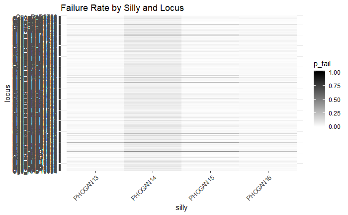

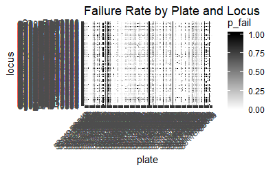

```r
project <- "NPRB"
failure_rate <- FailureRate.GCL(sillyvec = ProjectSillys_Origin)
failure_rate_noplots <- failure_rate[1:4]
save_objects("failure_rate_noplots", "../Objects/")
failure_rate
```

We can see some very specific plate effects, we tried to address some of these QC re-runs project, but clearly some just have bad tissues. It also appears that there are a few markers that consistently fail. Also of note, 2014 had a higher failure rate that other years, I suspect that this is due to some field sampling issues from that year (i.e. evaporation of ethanol from DWPs).

# QA

Go through our standard Quality Assurance (QA) process, then explore heterozygosity. Produce a matrix with sample sizes.

```r
ProjectSillys_Origin_SampleSizes <- matrix(data = NA, nrow = length(ProjectSillys_Origin), ncol = 5, dimnames = list(ProjectSillys_Origin, c("Genotyped", "Missing", "Duplicate", "Heterozygosity", "Final")))
ProjectSillys_Origin_SampleSizes[, "Genotyped"] <- sapply(paste0(ProjectSillys_Origin, ".gcl"), function(x) get(x)$n)
```

## Missing

Remove individuals missing >=20% of genotypes (i.e. the 80% rule).

```r
MissLoci <- RemoveIndMissLoci.GCL(sillyvec = ProjectSillys_Origin, proportion = 0.8)
MissLoci  # character vector of fish removed
```

```
$`PHOGAN13n`
 [1] "2"   "3"   "19"  "36"  "64"  "81"  "279" "285" "288" "289" "299" "334"

$PHOGAN13h
 [1] "1"   "15"  "32"  "341" "342" "373" "376" "395" "399" "401" "404" "459"

$PHOGAN14n
 [1] "34"  "37"  "40"  "110" "115" "176" "184" "189" "190" "199" "200" "222" "224" "225" "231" "232" "233" "235" "237"

$PHOGAN14h
 [1] "18"  "36"  "266" "276" "336" "337" "339" "345" "346" "347" "349" "350" "352" "353" "354" "355" "358" "368" "377" "396" "437" "438"
[23] "440" "441" "442" "443" "444" "445" "446" "447" "456" "458" "460" "462" "464" "476" "478" "481" "482" "490" "492" "493" "494" "495"
[45] "496" "497" "498" "502" "503" "504" "512"

$PHOGAN15
 [1] "1295" "2011" "2146" "2161" "3851" "3949" "4032" "4052" "4114" "4212" "4213" "4214" "4216" "4334" "4989" "5011" "5096" "5164" "5173"
[20] "5181" "5202" "5370" "5372" "5374" "5378" "5390" "5394" "5401" "5469" "5546" "5651" "5652" "5659" "5669" "5942" "7019" "7218" "7308"
[39] "7389" "9284" "9285" "9295"

$PHOGAN16
  [1] "89"    "264"   "315"   "361"   "373"   "411"   "431"   "538"   "878"   "932"   "1162"  "1172"  "1260"  "1285"  "1662"  "1997"  "2020"
 [18] "2064"  "2068"  "2131"  "2688"  "3124"  "3128"  "3138"  "3167"  "3170"  "3172"  "3203"  "3823"  "3872"  "3902"  "3964"  "3974"  "3987"
 [35] "4283"  "4602"  "4612"  "4642"  "4653"  "4661"  "4664"  "4835"  "5126"  "5567"  "5827"  "6555"  "6564"  "6567"  "7015"  "7017"  "7021"
 [52] "7054"  "7415"  "7458"  "8670"  "8671"  "8707"  "8764"  "8771"  "8772"  "8778"  "9383"  "9388"  "9414"  "9474"  "9481"  "9521"  "9522"
 [69] "9785"  "9793"  "9798"  "9806"  "9818"  "9819"  "9823"  "9826"  "9828"  "9842"  "9875"  "9904"  "9905"  "9909"  "9946"  "9964"  "9971"
 [86] "9984"  "9985"  "10048" "10103" "10176" "10177" "10180" "10185" "10267" "10342" "10362" "10473" "10479" "10550" "10765" "10767" "10774"
[103] "10790" "10796" "10799" "11464" "11471" "11478" "11483" "11490" "11498" "11503" "11511" "11536" "12007" "12303" "12396"
```

```r
save_objects("MissLoci", path = "../Objects/")
ProjectSillys_Origin_SampleSizes[, "Missing"] <-  ProjectSillys_Origin_SampleSizes[, "Genotyped"] - sapply(paste0(ProjectSillys_Origin, ".gcl"), function(x) get(x)$n)
```

## Duplicate

Remove duplicate individuals within the same collection. Typically we specify *duplicates* as a pair of individuals that share >=95% of genotypes. Once a pair of *duplicates* is identified, we keep the individual with the most genotypes and remove the other.

```r
DuplicateCheck95MinProportion <- CheckDupWithinSilly.GCL(sillyvec = ProjectSillys_Origin, loci = loci, quantile = NULL, minproportion = 0.95)
DuplicateCheckReportSummary <- sapply(ProjectSillys_Origin, function(x) DuplicateCheck95MinProportion[[x]]$report, simplify = FALSE)
DuplicateCheckReportSummary
```

```
$`PHOGAN13n`
[1] "NO Duplicates"

$PHOGAN13h
```

| ID1 | ID2 | Missing1 | Missing2 | proportion |
| --- | --- | --- | --- | --- |
| 273 | 272 | 0 | 0 | 0.9932886 |
| 454 | 456 | 0 | 0 | 0.9697987 |

```
$PHOGAN14n
[1] "NO Duplicates"

$PHOGAN14h
```

| ID1 | ID2 | Missing1 | Missing2 | proportion |
| --- | --- | --- | --- | --- |
| 199 | 200 | 0 | 0 | 1 |

| ID1 | ID2 | Missing1 | Missing2 | proportion |
| --- | --- | --- | --- | --- |
| 3218 | 3217 | 0 | 0 | 0.9832215 |

| ID1 | ID2 | Missing1 | Missing2 | proportion |
| --- | --- | --- | --- | --- |
| 12448 | 9721 | 0 | 0 | 0.9731544 |
| 3923 | 3922 | 0 | 0 | 0.9798658 |
| 5691 | 5684 | 0 | 0 | 0.9966443 |
| 12041 | 12040 | 0 | 0 | 0.9865772 |
| 11811 | 11812 | 0 | 0 | 0.9798658 |
| 10544 | 10553 | 0 | 0 | 1.0000000 |

```r
save_objects("DuplicateCheckReportSummary", path = "../Objects/")
```

```r
RemoveIDs.GCL(silly = "PHOGAN16", IDs = dup_16_ids)
```

## Heterozygosity

We know from the QC work that the **GTscore** genotyping pipeline can sometimes result in individuals with an overabundance of heterozygous calls (perhaps from contamination?). We want to remove individuals with untrustworth genotypes. In order to explore the utility of some sort of *heterozygosity filter*, we should first plot a histogram of heterozygosity per individual to see what the problem looks like. From there we can set a threshold or range of acceptable heterozygosities.

### Plot by silly

Plot with *tidyverse* for ease of use/visualization. Add +- 3SD cutoff from literature (Anderson et al. 2010).

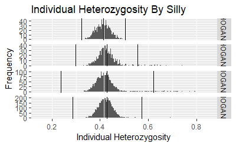

After discussions with Chris, Tyler, and Dan, we decided that it would be more appropriate to examine heterozygosity by lineage (even versus odd) instead of year. Additionally, we all agreed that the +-3SD cutoff was not restrictive enough, the upper bound for the cutoff should be closer to the main distribution.

### Plot by lineage

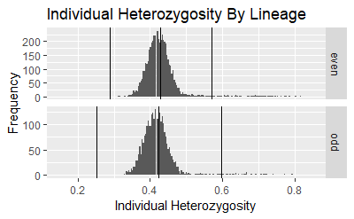

How many fish would we lose if we went with these cutoffs?

```r
# Upper cutoff only, lower doesn't apply
het_tibble %>%
  dplyr::group_by(lineage) %>%
  dplyr::summarise(upper = mean(het) + 3* sd(het)) %>%
  dplyr::right_join(het_tibble) %>%
  dplyr::filter(het >= upper) %>%
  dplyr::count(lineage)
```

| lineage | n |
| --- | --- |
| even | 101 |
| odd | 80 |

### Cutoffs to remove outliers

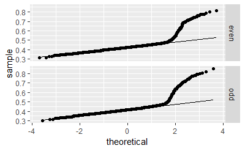

| lineage | low_1.5_IQR | high_1.5_IQR |
| --- | --- | --- |
| even | 0.3506711 | 0.4983221 |
| odd | 0.3355705 | 0.4966443 |

Chris suggested that we stick with the +-3SD approach, however, before calculating the SD, we mirror the left hand side of the distribution to the right (assuming the **mode** should be the **mean**).

[output not shown]

Now lets look at all three of these approaches on the original histograms.

1. +-3SD by lineage
2. 1.5 IQR +- 75% and 25% quartiles
3. Chris’ +-3SD by lineage only using the left hand side of the distribution.

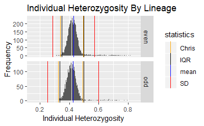

We can see that the upper bound is virtually identical for both Chris’ method and IQR. We proposed that we go with the 1.5 IQR method given that it is well known and well documented. All agreed.

### Remove fish with IQR cutoff

Now that we’ve decided to use the 1.5IQR, how many fish are we going to remove from each silly?

| silly | n |
| --- | --- |
| PHOGAN13 | 3 |
| PHOGAN14 | 28 |
| PHOGAN15 | 143 |
| PHOGAN16 | 172 |

Now remove those fish. Figure out which ones they are, convert *SillySource* to *FK_FISH_ID* (**note**: the values for *FK_FISH_ID* got reassigned after pooling), remove them.

```r
RemoveIDs.GCL(silly = "PHOGAN16", IDs = PHOGAN16_hets_remove)
```

## Final

How many fish did we end up with?

```r
ProjectSillys_Origin_SampleSizes[, "Final"] <- sapply(paste0(ProjectSillys_Origin, ".gcl"), function(x) get(x)$n)
ProjectSillys_Origin_SampleSizes
```

```
          Genotyped Missing Duplicate Heterozygosity Final
PHOGAN13n       334      12         0              1   321
PHOGAN13h       461      12         4              2   443
PHOGAN14n       239      19         0              6   214
PHOGAN14h       512      51         2             22   437
PHOGAN15       2100      42         2            143  1913
PHOGAN16       4295     117        12            172  3994
```

```r
save_objects("ProjectSillys_Origin_SampleSizes", path = "../Objects/")
```

Save post-QA genotypes.

```r
save_sillys(ProjectSillys_Origin, "../Genotypes/298/OceanAK_Origin_PostQA/")
```

# Export genepop file

Now that we have final, post QA/QC genotypes, we want to save our work by exporting the genotypes as a **Genepeop** file. That **Genepop** file will then feed in to Chase’s *genepop2franz.GCL.r* script to create a **FRANz** input file for parentage analysis!

Create a *genepop* using `gcl2Genepop.GCL`, individuals are named by *SillySource*.

```r
gcl2Genepop.GCL(sillyvec = c("PHOGAN13n", "PHOGAN13h", "PHOGAN14n", "PHOGAN14h", "PHOGAN15", "PHOGAN16"),
                loci = loci,
                path = "../Genepop/hogan_postQA.gen",
                VialNums = TRUE,
                usat = FALSE)
```

```r
gcl2Genepop.GCL(sillyvec = c("PHOGAN13n", "PHOGAN13h", "PHOGAN15"),
                loci = loci,
                path = "../Genepop/hogan_odd_postQA.gen",
                VialNums = TRUE,
                usat = FALSE)
```

```r
gcl2Genepop.GCL(sillyvec = c("PHOGAN14n", "PHOGAN14h", "PHOGAN16"),
                loci = loci,
                path = "../Genepop/hogan_even_postQA.gen",
                VialNums = TRUE,
                usat = FALSE)
```

# Convert genepop to Franz

```r
genepop2franz.GCL("../Genepop/hogan_postQA.gen", "../OceanAK/PedigreeData_AHRP - Salmon Biological Data 2_PWS_2013-2018_no_otoliths.csv", c(2014, 2016), "HOGAN", "../")
```

```
 Converting data from a Genepop .gen file to a genind object...


File description:  GENEPOP input format

...done.
```